# Efficient Frontier and Optimal Risky Portfolios: An Empirical and Simulation Study

This notebook explores the construction of **efficient frontiers** and **optimal risky portfolios (ORPs)** using stock return data. The analysis is carried out in three stages:

### 1. Empirical Efficient Frontiers (2010–2019)

- Data is split into three windows: **2010–2013**, **2014–2017**, and **2018–2019**.
- For each period, we compute the efficient frontier using sample means and covariances, and identify the **Optimal Risky Portfolio** (maximum Sharpe ratio).
- Portfolio weights, expected returns, volatilities, and Sharpe ratios are compared across periods.

### 2. Out-of-Sample Testing

- The ORPs from 2010–2013 and 2014–2017 are evaluated using **2018–2019 returns**.
- This shows how efficient portfolios derived from historical data perform under new market conditions.
- Results highlight that while earlier ORPs remain serviceable, they generally fall **below the efficient frontier** when tested out-of-sample.

### 3. Appendix: Estimation Risk Illustration

- To illustrate why ORPs degrade out-of-sample, we simulate **“noisy” efficient frontiers** using synthetic data drawn from a known distribution.
- Comparing these noisy frontiers to the true frontier demonstrates how estimation error **inflates in-sample Sharpe ratios** and pushes portfolios off the true frontier.
- This reinforces the empirical findings: mean–variance optimization magnifies noise in expected returns and covariances, leading to portfolios that may look optimal historically but **lose efficiency when conditions change**.

```python
import numpy as np
import pandas as pd
from scipy.optimize import minimize
import matplotlib.pyplot as plt

pd.set_option("display.float_format", lambda x: f"{x:,.6f}")
```

```python
csv_path = "/content/A_Stock_Returns.csv"

df = pd.read_csv(
    csv_path,
    index_col=0,
    parse_dates=True,
    usecols=["Date", "AAPL", "JPM", "NKE", "T"]
)

display(df.head())
print("Shape:", df.shape)
print("Date range:", df.index.min().date(), "to", df.index.max().date())
```

| Date | AAPL | JPM | NKE | T |
| --- | --- | --- | --- | --- |
| 2010-01-04 00:00:00+00:00 | 0.015436 | 0.030291 | -0.010957 | 0.019432 |
| 2010-01-05 00:00:00+00:00 | 0.001727 | 0.019185 | 0.003971 | -0.004911 |
| 2010-01-06 00:00:00+00:00 | -0.016034 | 0.005479 | -0.006115 | -0.014521 |
| 2010-01-07 00:00:00+00:00 | -0.001850 | 0.019615 | 0.009767 | -0.011291 |
| 2010-01-08 00:00:00+00:00 | 0.006626 | -0.002459 | -0.001976 | -0.007353 |

```
Shape: (2516, 4)
Date range: 2010-01-04 to 2019-12-31
```

```python
stock_name = df.columns
```

```python
df_20102013 = df.loc["2010-01-01":"2013-12-31"]
df_20142017 = df.loc["2014-01-01":"2017-12-31"]
df_20182019 = df.loc["2018-01-01":"2019-12-31"]

print("2010–2013:", df_20102013.shape, df_20102013.index.min().date(), "to", df_20102013.index.max().date())
print("2014–2017:", df_20142017.shape, df_20142017.index.min().date(), "to", df_20142017.index.max().date())
print("2018–2019:", df_20182019.shape, df_20182019.index.min().date(), "to", df_20182019.index.max().date())
```

```
2010–2013: (1006, 4) 2010-01-04 to 2013-12-31
2014–2017: (1007, 4) 2014-01-02 to 2017-12-29
2018–2019: (503, 4) 2018-01-02 to 2019-12-31
```

```python
cov_df_20102013 = df_20102013.cov().values
cov_df_20142017 = df_20142017.cov().values
mu_df_20102013  = df_20102013.mean().values
mu_df_20142017  = df_20142017.mean().values

print("cov 2010–2013:", cov_df_20102013.shape, "| mu:", mu_df_20102013.shape)
print("cov 2014–2017:", cov_df_20142017.shape, "| mu:", mu_df_20142017.shape)
```

```
cov 2010–2013: (4, 4) | mu: (4,)
cov 2014–2017: (4, 4) | mu: (4,)
```

```python
no_stocks = len(df_20102013.columns)
no_stocks
```

```
4
```

```python
def min_variance(cov, mu=None, desired_ret=None):

    n = cov.shape[0]

    def variance(w):
        return w @ cov @ w

    cons = [{'type': 'eq', 'fun': lambda w: np.sum(w) - 1.0}]
    if desired_ret is not None:
        if mu is None:
            raise ValueError("mu must be provided when desired_ret is specified.")
        cons.append({'type': 'eq', 'fun': lambda w: w @ mu - desired_ret})

    init_guess = np.ones(n) / n  # neutral start

    res = minimize(
        variance,
        init_guess,
        method="SLSQP",
        bounds=None,                 # shorting allowed
        constraints=cons,
        options={"ftol": 1e-12, "maxiter": 10000, "disp": False}
    )
    if not res.success:
        raise RuntimeError(f"Optimization failed: {res.message}")

    w = res.x
    return variance(w), w
```

```python
min_variance(cov_df_20102013)
```

```
(np.float64(8.575063474509635e-05),
 array([ 0.11834828, -0.06269298,  0.16214735,  0.78219735]))
```

```python
min_variance(cov_df_20142017)
```

```
(np.float64(6.667016655521158e-05),
 array([0.15518849, 0.13856475, 0.17077022, 0.53547655]))
```

```python
desired_rets = np.linspace(-0.1, 0.5, 151) / 252
```

```python
def get_frontier(cov, mu, desired_rets, rf_daily):
    """
    Build efficient frontier by sweeping desired daily return targets.
    """

    rows = [min_variance(cov, mu, dr) for dr in desired_rets]

    df = pd.DataFrame(rows, columns=["Var_d", "Weights"])
    df["ER_d"] = desired_rets
    df["SD_d"] = np.sqrt(df["Var_d"])

    # Annualize
    df["ER_a"]  = 252 * df["ER_d"]
    df["Var_a"] = 252 * df["Var_d"]
    df["SD_a"]  = np.sqrt(252) * df["SD_d"]

    # Sharpe computed on an ANNUAL basis
    rf_a = 252 * rf_daily
    df["SR"] = (df["ER_a"] - rf_a) / df["SD_a"]

    return df
```

```python
frontier_20102013 = get_frontier(
    cov_df_20102013,        # daily covariance matrix for 2010–2013
    df_20102013.mean().values,  # daily mean returns vector for 2010–2013
    desired_rets,           # array of daily target returns (sweep from −10% to +50% annual)
    0.001/252               # daily risk-free rate (≈0.10% annualized)
)
```

```python
frontier_20102013
```

|  | Var_d | Weights | ER_d | SD_d | ER_a | Var_a | SD_a | SR |
| --- | --- | --- | --- | --- | --- | --- | --- | --- |
| 0 | 0.000619 | [-0.7536194801988441, 0.4573885656559251, -0.8... | -0.000397 | 0.024886 | -0.100000 | 0.156071 | 0.395058 | -0.255659 |
| 1 | 0.000602 | [-0.739623110562595, 0.4490403719837999, -0.85... | -0.000381 | 0.024543 | -0.096000 | 0.151789 | 0.389601 | -0.248973 |
| 2 | 0.000586 | [-0.7256266710839258, 0.4406921823915757, -0.8... | -0.000365 | 0.024200 | -0.092000 | 0.147576 | 0.384157 | -0.242089 |
| 3 | 0.000569 | [-0.7116304328403276, 0.4323441880632844, -0.8... | -0.000349 | 0.023857 | -0.088000 | 0.143433 | 0.378725 | -0.234999 |
| 4 | 0.000553 | [-0.6976339877946292, 0.4239962286009941, -0.8... | -0.000333 | 0.023516 | -0.084000 | 0.139359 | 0.373308 | -0.227694 |
| ... | ... | ... | ... | ... | ... | ... | ... | ... |
| 146 | 0.001049 | [1.2898505342513933, -0.7614349751461374, 1.55... | 0.001921 | 0.032386 | 0.484000 | 0.264305 | 0.514106 | 0.939495 |
| 147 | 0.001072 | [1.3038469125225451, -0.7697830947203734, 1.57... | 0.001937 | 0.032741 | 0.488000 | 0.270139 | 0.519749 | 0.936991 |
| 148 | 0.001095 | [1.3178433508167915, -0.7781311300066329, 1.58... | 0.001952 | 0.033097 | 0.492000 | 0.276042 | 0.525397 | 0.934532 |
| 149 | 0.001119 | [1.3318396254872567, -0.7864793212951043, 1.60... | 0.001968 | 0.033453 | 0.496000 | 0.282014 | 0.531050 | 0.932115 |
| 150 | 0.001143 | [1.3458361068779021, -0.794827262927246, 1.623... | 0.001984 | 0.033809 | 0.500000 | 0.288056 | 0.536708 | 0.929741 |

151 rows × 8 columns

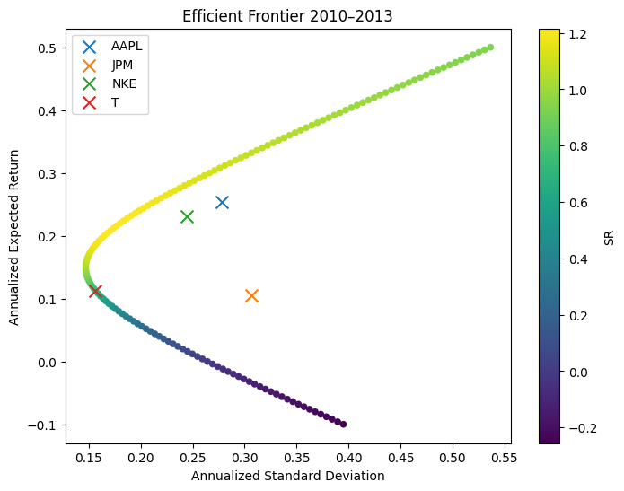

```python
ax = frontier_20102013.plot.scatter(
    x="SD_a", y="ER_a",
    title="Efficient Frontier 2010–2013",
    c="SR", cmap="viridis", figsize=(8,6)
)

for i in range(len(stock_name)):
    ax.scatter(
        x=np.sqrt(252 * cov_df_20102013[i, i]),
        y=252 * df_20102013.mean().values[i],
        label=stock_name[i], marker="x", s=100
    )

ax.set_xlabel("Annualized Standard Deviation")
ax.set_ylabel("Annualized Expected Return")
ax.legend()
```

```python
frontier_20142017 = get_frontier(cov_df_20142017,
                                 df_20142017.mean().values,
                                 desired_rets, 0.0026/252)
```

```python
frontier_20142017
```

|  | Var_d | Weights | ER_d | SD_d | ER_a | Var_a | SD_a | SR |
| --- | --- | --- | --- | --- | --- | --- | --- | --- |
| 0 | 0.000601 | [-0.8992536682824236, -0.7893599795151687, 0.3... | -0.000397 | 0.024505 | -0.100000 | 0.151330 | 0.389012 | -0.263745 |
| 1 | 0.000581 | [-0.8800506636060863, -0.7724611606066822, 0.3... | -0.000381 | 0.024109 | -0.096000 | 0.146475 | 0.382720 | -0.257629 |
| 2 | 0.000562 | [-0.8608477745033534, -0.7555621432481607, 0.3... | -0.000365 | 0.023714 | -0.092000 | 0.141709 | 0.376442 | -0.251300 |
| 3 | 0.000544 | [-0.8416447690645323, -0.7386632893088322, 0.3... | -0.000349 | 0.023319 | -0.088000 | 0.137032 | 0.370178 | -0.244747 |
| 4 | 0.000526 | [-0.8224417793646324, -0.7217643818227741, 0.3... | -0.000333 | 0.022925 | -0.084000 | 0.132444 | 0.363929 | -0.237958 |
| ... | ... | ... | ... | ... | ... | ... | ... | ... |
| 146 | 0.001536 | [1.9043799888502202, 1.6778797828251473, -0.13... | 0.001921 | 0.039189 | 0.484000 | 0.387010 | 0.622101 | 0.773829 |
| 147 | 0.001568 | [1.9235829875249704, 1.6947786046514601, -0.13... | 0.001937 | 0.039600 | 0.488000 | 0.395183 | 0.628636 | 0.772149 |
| 148 | 0.001601 | [1.9427861612438153, 1.7116772337339277, -0.14... | 0.001952 | 0.040012 | 0.492000 | 0.403445 | 0.635173 | 0.770499 |
| 149 | 0.001634 | [1.9619892984199447, 1.7285759440424757, -0.14... | 0.001968 | 0.040424 | 0.496000 | 0.411796 | 0.641714 | 0.768879 |
| 150 | 0.001668 | [1.9811921442057383, 1.7454749783509194, -0.14... | 0.001984 | 0.040836 | 0.500000 | 0.420237 | 0.648257 | 0.767288 |

151 rows × 8 columns

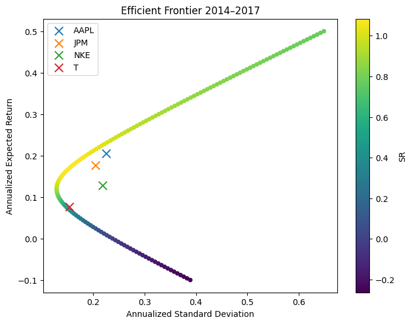

```python
ax = frontier_20142017.plot.scatter(
    x="SD_a", y="ER_a",
    title="Efficient Frontier 2014–2017",
    c="SR", cmap="viridis", figsize=(8,6)
)

for i in range(len(stock_name)):
    ax.scatter(
        x=np.sqrt(252 * cov_df_20142017[i, i]),
        y=252 * df_20142017.mean().values[i],
        label=stock_name[i], marker="x", s=100
    )

ax.set_xlabel("Annualized Standard Deviation")
ax.set_ylabel("Annualized Expected Return")
ax.legend()
```

```python
orp_20102013 = frontier_20102013.loc[frontier_20102013["SR"].idxmax()]
orp_20142017 = frontier_20142017.loc[frontier_20142017["SR"].idxmax()]

_, weights_20102013 = min_variance(cov_df_20102013, mu_df_20102013, orp_20102013["ER_d"])
_, weights_20142017 = min_variance(cov_df_20142017, mu_df_20142017, orp_20142017["ER_d"])

print("target vs achieved ER (annualized):")
print("2010–2013:", round(orp_20102013["ER_a"], 4), " ~ ", round(252 * float(weights_20102013 @ mu_df_20102013), 4))
print("2014–2017:", round(orp_20142017["ER_a"], 4), " ~ ", round(252 * float(weights_20142017 @ mu_df_20142017), 4))

orp_weights_df = pd.DataFrame(
    {
        "AAPL": [weights_20102013[0], weights_20142017[0]],
        "JPM":  [weights_20102013[1], weights_20142017[1]],
        "NKE":  [weights_20102013[2], weights_20142017[2]],
        "T":    [weights_20102013[3], weights_20142017[3]],
        "Expected Return (ann.)": [orp_20102013["ER_a"], orp_20142017["ER_a"]],
        "Volatility (ann. SD)":   [orp_20102013["SD_a"], orp_20142017["SD_a"]],
        "Sharpe (ann.)":          [orp_20102013["SR"],   orp_20142017["SR"]],
    },
    index=["2010–2013 ORP", "2014–2017 ORP"]
)

display(orp_weights_df.map(lambda x: f"{x:.4f}"))
```

```
target vs achieved ER (annualized):
2010–2013: 0.216  ~  0.216
2014–2017: 0.172  ~  0.172
```

|  | AAPL | JPM | NKE | T | Expected Return (ann.) | Volatility (ann. SD) | Sharpe (ann.) |
| --- | --- | --- | --- | --- | --- | --- | --- |
| 2010–2013 ORP | 0.3521 | -0.2021 | 0.4404 | 0.4096 | 0.2160 | 0.1768 | 1.2158 |
| 2014–2017 ORP | 0.4065 | 0.3598 | 0.1270 | 0.1067 | 0.1720 | 0.1564 | 1.0835 |

The table above reports the Optimal Risky Portfolios (ORPs) for each sample window. In 2010–2013, the ORP allocates heavily to NKE (44%) and AAPL (35%) while shorting JPM (−20%), with the remainder in T (41%). This portfolio achieves an annualized expected return of 21.6%, annual volatility of 17.7%, and a Sharpe ratio of 1.22, reflecting strong risk-adjusted performance but reliance on a short position.

By contrast, the 2014–2017 ORP shifts into a fully long allocation, concentrated in AAPL (41%) and JPM (36%) with smaller weights in NKE (13%) and T (11%). The expected return declines to 17.2% and volatility to 15.6%, yielding a lower Sharpe ratio of 1.08. This indicates a more balanced, less aggressive portfolio, but one that offered weaker risk-adjusted opportunities relative to the earlier period.

```python
cov_df_20182019 = df_20182019.cov().values
mu_df_20182019 = df_20182019.mean().values
```

```python
min_variance(cov_df_20182019)
```

```
(np.float64(0.00010854635260529249),
 array([0.08761161, 0.34365989, 0.16509484, 0.40363366]))
```

```python
frontier_20182019 = get_frontier(cov_df_20182019,
                                 df_20182019.mean().values,
                                 desired_rets, 0.02/252)
```

```python
frontier_20182019
```

|  | Var_d | Weights | ER_d | SD_d | ER_a | Var_a | SD_a | SR |
| --- | --- | --- | --- | --- | --- | --- | --- | --- |
| 0 | 0.000453 | [-0.6571188595825413, 0.6784237521765658, -0.4... | -0.000397 | 0.021279 | -0.100000 | 0.114102 | 0.337789 | -0.355251 |
| 1 | 0.000442 | [-0.6450638026025844, 0.6730048582472485, -0.3... | -0.000381 | 0.021017 | -0.096000 | 0.111316 | 0.333641 | -0.347680 |
| 2 | 0.000431 | [-0.6330087391456097, 0.6675859826983431, -0.3... | -0.000365 | 0.020757 | -0.092000 | 0.108576 | 0.329508 | -0.339900 |
| 3 | 0.000420 | [-0.6209536794933547, 0.6621671141448597, -0.3... | -0.000349 | 0.020498 | -0.088000 | 0.105881 | 0.325394 | -0.331906 |
| 4 | 0.000410 | [-0.6088986307219482, 0.6567482890507562, -0.3... | -0.000333 | 0.020240 | -0.084000 | 0.103232 | 0.321297 | -0.323688 |
| ... | ... | ... | ... | ... | ... | ... | ... | ... |
| 146 | 0.000748 | [1.1029202832542009, -0.11273162180456398, 0.9... | 0.001921 | 0.027356 | 0.484000 | 0.188588 | 0.434267 | 1.068466 |
| 147 | 0.000764 | [1.114975389584083, -0.11815037564635157, 0.95... | 0.001937 | 0.027634 | 0.488000 | 0.192440 | 0.438679 | 1.066839 |
| 148 | 0.000779 | [1.1270303658891325, -0.12356938438678246, 0.9... | 0.001952 | 0.027913 | 0.492000 | 0.196336 | 0.443099 | 1.065225 |
| 149 | 0.000795 | [1.1390854369621801, -0.1289883888040461, 0.97... | 0.001968 | 0.028191 | 0.496000 | 0.200279 | 0.447525 | 1.063627 |
| 150 | 0.000811 | [1.1511405364722804, -0.13440693801305975, 0.9... | 0.001984 | 0.028471 | 0.500000 | 0.204267 | 0.451959 | 1.062044 |

151 rows × 8 columns

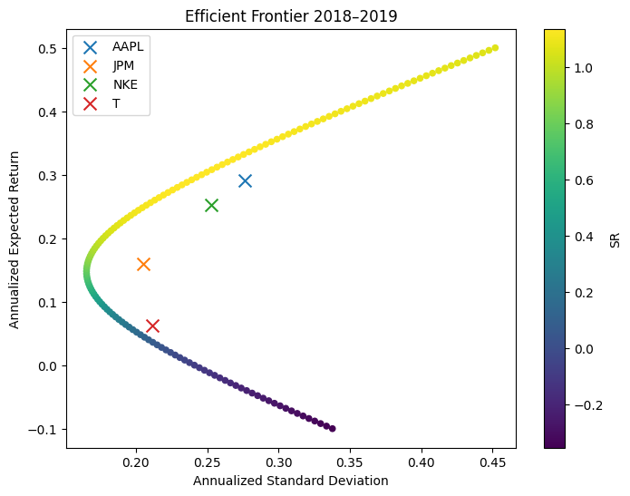

```python
ax = frontier_20182019.plot.scatter(
    x="SD_a", y="ER_a",
    title="Efficient Frontier 2018–2019",
    c="SR", cmap="viridis", figsize=(8,6)
)

for i in range(len(stock_name)):
    ax.scatter(
        x=np.sqrt(252 * cov_df_20182019[i, i]),
        y=252 * df_20182019.mean().values[i],
        label=stock_name[i], marker="x", s=100
    )

ax.set_xlabel("Annualized Standard Deviation")
ax.set_ylabel("Annualized Expected Return")
ax.legend()
```

```python
orp_20182019 = frontier_20182019.loc[frontier_20182019["SR"].idxmax()]
_, w_orp_2018_2019 = min_variance(cov_df_20182019, mu_df_20182019, orp_20182019["ER_d"])
w_orp_2018_2019
```

```
array([ 0.54860348,  0.13570323,  0.52059134, -0.20489805])
```

```python
orp_weights_20182019 = pd.DataFrame(
    {
        "AAPL": [w_orp_2018_2019[0]],
        "JPM":  [w_orp_2018_2019[1]],
        "NKE":  [w_orp_2018_2019[2]],
        "T":    [w_orp_2018_2019[3]],
        "Expected Return (ann.)": [orp_20182019["ER_a"]],
        "Volatility (ann. SD)":   [orp_20182019["SD_a"]],
        "Sharpe (ann.)":          [orp_20182019["SR"]],
    },
    index=["2018–2019 ORP"]
)

display(orp_weights_20182019.round(4))
```

|  | AAPL | JPM | NKE | T | Expected Return (ann.) | Volatility (ann. SD) | Sharpe (ann.) |
| --- | --- | --- | --- | --- | --- | --- | --- |
| 2018–2019 ORP | 0.548600 | 0.135700 | 0.520600 | -0.204900 | 0.300000 | 0.246100 | 1.137800 |

The 2018–2019 ORP achieves the highest expected return of the three sample windows (30%) but also comes with the highest volatility (24.6%). The Sharpe ratio of 1.14 is stronger than the 2014–2017 ORP (≈1.08) but a bit weaker than the 2010–2013 ORP (≈1.22). The reliance on a short position in T indicates that in this window, T’s risk/return profile detracted from efficiency, so the optimizer excluded it by going net short.

```python
portfolio_20102013 = df_20182019 @ weights_20102013
portfolio_20142017 = df_20182019 @ weights_20142017

orp_ret_2010_2013 = 252 * portfolio_20102013.mean()
orp_sd_2010_2013 = np.sqrt(252) * portfolio_20102013.std()

orp_ret_2014_2017 = 252 * portfolio_20142017.mean()
orp_sd_2014_2017 = np.sqrt(252) * portfolio_20142017.std()
```

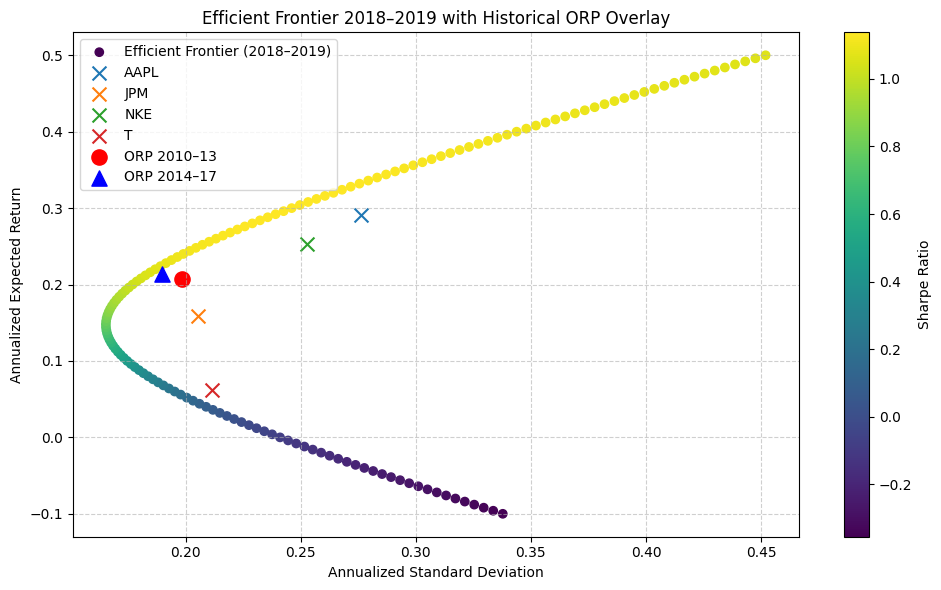

```python
fig, ax = plt.subplots(figsize=(10, 6))

sc = ax.scatter(
    frontier_20182019["SD_a"], frontier_20182019["ER_a"],
    c=frontier_20182019["SR"], cmap="viridis",
    label="Efficient Frontier (2018–2019)"
)

for i in range(len(stock_name)):
    ax.scatter(
        x=np.sqrt(252 * cov_df_20182019[i, i]),
        y=252 * df_20182019.mean().values[i],
        label=stock_name[i], marker="x", s=100
    )

# Overlay ORPs from earlier periods, evaluated out-of-sample
ax.scatter(
    orp_sd_2010_2013, orp_ret_2010_2013,
    color="red", marker="o", s=120, label="ORP 2010–13"
)
ax.scatter(
    orp_sd_2014_2017, orp_ret_2014_2017,
    color="blue", marker="^", s=120, label="ORP 2014–17"
)

# Labels
ax.set_title("Efficient Frontier 2018–2019 with Historical ORP Overlay")
ax.set_xlabel("Annualized Standard Deviation")
ax.set_ylabel("Annualized Expected Return")
ax.legend()
ax.grid(True, linestyle="--", alpha=0.6)

plt.colorbar(sc, label="Sharpe Ratio")

plt.tight_layout()
plt.show()
```

The overlay shows that both the 2010–2013 and 2014–2017 Optimal Risky Portfolios remained reasonably close to the 2018–2019 efficient frontier, with returns around 21–22% and volatility near 19–20%. However, they did not lie on the frontier itself, indicating reduced efficiency out-of-sample. The 2018–2019 frontier favors heavier allocations to AAPL and NKE with a short in T, delivering higher Sharpe ratios than the historical ORPs could achieve.

## Conclusion

Across the three sample windows, the optimal risky portfolios highlight how changes in the return–covariance structure drive significant shifts in efficient allocations.

**2010–2013 ORP delivered the highest Sharpe ratio (≈1.22), but required a short position in JPM.**

**2014–2017 ORP was more balanced and fully long, yet efficiency weakened with a lower Sharpe (≈1.08)**.

**2018–2019 ORP produced the highest expected return (≈30%) at the cost of the highest volatility (≈24.6%).** Its **Sharpe (≈1.14)** fell between the earlier windows, with allocations dominated by AAPL and NKE and a short in T, reflecting T’s weak risk–return contribution.

The out-of-sample test reinforces these findings: historical ORPs from 2010–2013 and 2014–2017 performed reasonably well in 2018–2019, landing close to the frontier but below the optimal set. This illustrates both the persistence and the limitations of in-sample optimality — portfolios built on past data may remain serviceable, but they rarely stay fully efficient when the market environment shifts.

Overall, the analysis demonstrates the importance of re-estimating mean–variance inputs over time and treating historical ORPs as guides rather than static prescriptions.

## Appendix: Estimation Risk and Noisy Frontiers

While the analysis above focused on empirical data, it is important to recognize that mean–variance optimization is highly sensitive to estimation error. Even small differences in expected returns or covariances can shift the efficient frontier and the composition of the optimal portfolio. To illustrate this, we simulate returns from a known “true” distribution and compare the resulting noisy frontiers (based on finite samples) against the true frontier. This highlights how sampling noise can create large deviations and why portfolios that look optimal in-sample may perform less efficiently out-of-sample.

```python
mu_th = (np.array([0.12, 0.10, 0.10, 0.06]))/252
cov_th = (np.array([
    [625, 450, 113, -25],
    [450, 400,  90, -45],
    [113,  90, 225, -60],
    [-25, -45, -60, 100]
]) / 10000) / 252
rf = 0.02 / 252
```

```python
def random_frontier(mu_true, cov_true, rf,
                    n_pts=75, max_ann_ret=0.30, min_ann_ret=-0.05):

    sim_returns = np.random.multivariate_normal(mu_true, cov_true, size=100)

    mu_emp  = sim_returns.mean(axis=0)
    cov_emp = np.cov(sim_returns.T)

    lo_cap = min_ann_ret / 252.0
    hi_cap = max_ann_ret / 252.0

    lo = max(lo_cap, np.min(mu_emp) * 0.5)     # allow a bit negative
    hi = min(hi_cap, np.max(mu_emp) * 1.5)     # avoid crazy leverage

    # fallback if too narrow
    if hi <= lo:
        hi = lo + 1e-5

    sample_desired_rets = np.linspace(lo, hi, n_pts)

    return get_frontier(cov_emp, mu_emp, sample_desired_rets, rf)
```

```python
np.random.seed(99)

noisy_frontiers = [random_frontier(mu_th, cov_th, rf) for _ in range(4)]
true_frontier = get_frontier(cov_th, mu_th, desired_rets, rf)
```

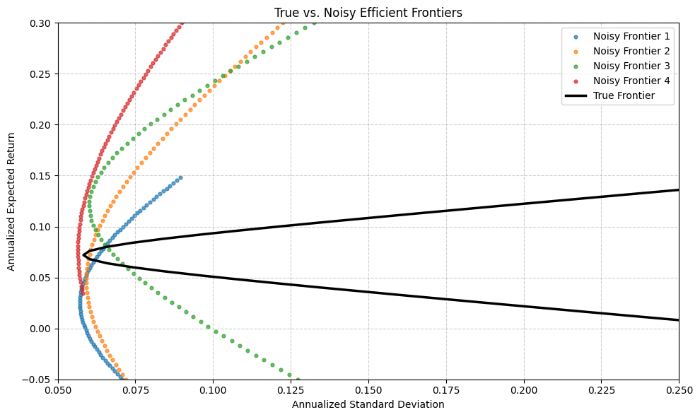

```python
import matplotlib as mpl

fig, ax = plt.subplots(figsize=(10, 6))

colors = mpl.cm.tab10.colors

for i, f in enumerate(noisy_frontiers):
    ax.scatter(
        f["SD_a"], f["ER_a"],
        label=f"Noisy Frontier {i+1}",
        color=colors[i % len(colors)],
        s=12, alpha=0.7
    )

ax.plot(
    true_frontier["SD_a"], true_frontier["ER_a"],
    color="black", linewidth=2.5, label="True Frontier"
)

# labels and style
ax.set_title("True vs. Noisy Efficient Frontiers")
ax.set_xlabel("Annualized Standard Deviation")
ax.set_ylabel("Annualized Expected Return")
ax.legend()
ax.grid(True, linestyle="--", alpha=0.6)
ax.set_xlim(0.05, 0.25)
ax.set_ylim(-0.05, 0.30)

plt.tight_layout()
plt.show()
```

The noisy frontiers appear shifted to the left of the true curve, suggesting higher returns at lower risk. This is an artifact of estimation error: small samples tend to overstate Sharpe ratios and produce frontiers that look unrealistically efficient. In reality, the true frontier is flatter and less favorable.

This visualization highlights the central limitation of mean–variance optimization: while portfolios can appear optimal in-sample, estimation noise in expected returns and covariances can lead to overfitting and degraded out-of-sample performance. This helps explain why the historical ORPs from 2010–2013 and 2014–2017 did not remain perfectly efficient when tested on 2018–2019 data.

```python
sr_noisy = [front.loc[front.SR.idxmax(), "SR"] for front in noisy_frontiers]
sr_true = true_frontier.loc[true_frontier.SR.idxmax(), "SR"]
```

```python
sr_df = pd.DataFrame({
    "Noisy Frontier Sharpe": sr_noisy,
    "True Frontier Sharpe": [sr_true] * len(sr_noisy)
}, index=[f"Noisy {i+1}" for i in range(len(sr_noisy))])

display(sr_df.round(4))
```

|  | Noisy Frontier Sharpe | True Frontier Sharpe |
| --- | --- | --- |
| Noisy 1 | 1.430100 | 0.930300 |
| Noisy 2 | 2.286300 | 0.930300 |
| Noisy 3 | 2.260700 | 0.930300 |
| Noisy 4 | 3.114400 | 0.930300 |

The table compares the maximum Sharpe ratios achieved on each noisy frontier to the true frontier’s Sharpe ratio. The true maximum Sharpe is about 0.93, while the noisy frontiers report inflated values ranging from 1.43 to over 3.11.

This discrepancy is a direct result of estimation error. With only 100 simulated returns, the empirical means and covariances are noisy. When these are fed into mean–variance optimization, the optimizer “chases the noise,” producing portfolios that look extremely efficient in-sample but are not achievable in reality.

This highlights a core limitation of mean–variance optimization: the optimizer magnifies errors in estimated inputs, often leading to overfit portfolios that appear much better in-sample than they perform out-of-sample. It ties back to the earlier finding that historical ORPs (2010–2013 and 2014–2017) underperformed when tested on 2018–2019 data.

```python
opt_w_noisy = [
    frontier.loc[frontier.SR.idxmax(), "Weights"] for frontier in noisy_frontiers]
```

```python
true_returns = []
true_vol = []
true_sr = []

for w in opt_w_noisy:
    w = np.array(w)
    ret = (w @ mu_th) * 252  # annualized expected return under true μ
    vol = np.sqrt(w.T @ cov_th @ w) * np.sqrt(252)  # annualized vol under true Σ
    sharpe = (ret - 0.02) / vol  # true Sharpe, 2% rf

    true_returns.append(ret)
    true_vol.append(vol)
    true_sr.append(sharpe)

true_df = pd.DataFrame({
    "True Return": true_returns,
    "True Volatility": true_vol,
    "Sharpe (True μ, Σ)": true_sr
}, index=[f"Noisy {i+1}" for i in range(len(opt_w_noisy))])

display(true_df.round(4))
```

|  | True Return | True Volatility | Sharpe (True μ, Σ) |
| --- | --- | --- | --- |
| Noisy 1 | 0.073200 | 0.091800 | 0.579600 |
| Noisy 2 | 0.063700 | 0.127300 | 0.343400 |
| Noisy 3 | 0.061900 | 0.077900 | 0.537600 |
| Noisy 4 | 0.083600 | 0.089900 | 0.706800 |

The table reports how the “optimal” noisy portfolios perform when evaluated against the true mean and covariance. Although the noisy frontiers suggested extremely high Sharpe ratios (1.4–3.1), their true risk-adjusted performance is much lower, with Sharpe ratios ranging only from 0.34 to 0.71.

Noisy 4 achieved the best true Sharpe (0.71), with strong return and modest volatility.

Noisy 2 looks especially overfit: it had one of the highest in-sample Sharpe ratios (>2.2) but delivered the weakest true Sharpe (0.34).

Noisy 1 and Noisy 3 achieved intermediate true Sharpe ratios (~0.54–0.58), but still far below their inflated in-sample values.

This reinforces the message: estimation noise can drastically inflate in-sample efficiency, and portfolios that appear optimal with limited data often underperform when measured against the true distribution. It echoes the empirical finding that historical ORPs from earlier periods (2010–2013, 2014–2017) did not remain perfectly efficient in 2018–2019.

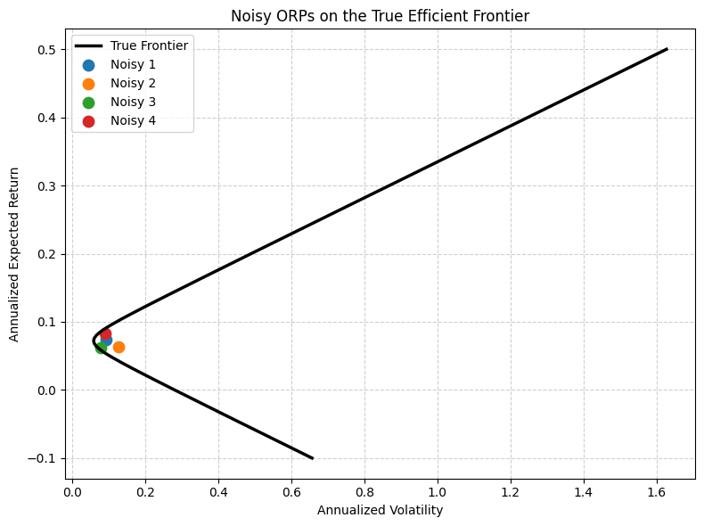

```python
fig, ax = plt.subplots(figsize=(8,6))

# True frontier
ax.plot(true_frontier["SD_a"], true_frontier["ER_a"],
        color="black", linewidth=2.5, label="True Frontier")

# Noisy ORPs
for i, (ret, vol) in enumerate(zip(true_returns, true_vol)):
    ax.scatter(vol, ret, s=80, label=f"Noisy {i+1}")

ax.set_title("Noisy ORPs on the True Efficient Frontier")
ax.set_xlabel("Annualized Volatility")
ax.set_ylabel("Annualized Expected Return")
ax.grid(True, linestyle="--", alpha=0.6)
ax.legend()
plt.tight_layout()
plt.show()
```

The noisy ORPs fall below the true efficient frontier, showing they are not truly optimal once evaluated against the underlying distribution. This illustrates how sampling error can create portfolios that look highly efficient in-sample but underperform in reality. It reinforces the main finding from the empirical analysis: **mean–variance optimization is highly sensitive to estimation error, and historical ORPs often lose efficiency out-of-sample.**